# SciPy를 이용한 확률 분포 분석

> SciPy는 각종 수치 해석 기능을 제공하는 파이썬 패키지

> SciPy는 여러개의 서브 패키지로 구성되어 있는데 그 중 **scipy.stats** 서브패키지는 여러가지 확률 분포 분석을 위한 기능을 제공한다.

## 확률 분포 객체

SciPy에서 확률 분포 기능을 사용하려면 우선 해당 확률 분포에 대한 확률 분포 객체라는 것을 생성한 후에 이 객체의 메서드를 호출한다.

확률 분포 객체를 생성하는 명령에는 다음과 같은 것들이 있다.

| 종류 | 이름 | 확률 분포 |
| --- | --- | --- |
| 이산 | `bernoulli` | 베르누이 분포 |
| 이산 | `binom` | 이항 분포 |
| 연속 | `uniform` | 균일 분포 |
| 연속 | `norm` | 가우시안 정규 분포 |
| 연속 | `beta` | 베타 분포 |
| 연속 | `gamma` | 감마 분포 |
| 연속 | `t` | 스튜던트 t 분포 |
| 연속 | `chi2` | 카이 제곱 분포 |
| 연속 | `f` | F 분포 |
| 연속 | `dirichlet` | 디리클리 분포 |
| 연속 | `multivariate_normal` | 다변수 가우시안 정규 분포 |

### 주의!! scipy.stats를 사용하려면 아래 seaborn 모듈과 함께 import를 해주어야만 실행이 된다!

```python
# -*- coding: utf-8 -*-

import scipy as sp
import seaborn as sns
import numpy as np
import matplotlib as mpl
import matplotlib.pylab as plt
%matplotlib inline
```

```python
rv = sp.stats.norm()
```

```python
type(rv)
```

```
scipy.stats._distn_infrastructure.rv_frozen
```

### 모수 지정

확률 분포 객체를 생성할 때는 분포의 모수(parameter)를 인수로 지정해 주어야 한다. 각 확률 분포마다 지정해 주어야 할 모수가 다르므로 자세한 설명은 문서를 참조하여야 하지만 대부분 다음과 같은 모수들을 공통적으로 가진다.

| 모수 또는 인수 | 의미 |
| --- | --- |
| `loc` | 일반적으로 분포의 기댓값 |
| `scale` | 일반적으로 분포의 표준편차 |
| `size` | 샘플 생성시 생성될 샘플의 크기 |
| `random_state` | 샘플 생성시 사용되는 시드(seed)값 |

예를 들어 기댓값이 1이고 표준 편차가 2인 정규 분포 객체는 다음과 같이 생성한다.

```python
rv = sp.stats.norm(loc=1, scale=2)
```

## 확률 분포 메서드

확률 분포 객체가 가지는 메서드는 다음과 같다.

| 메서드 | 기능 |
| --- | --- |
| `pdf` | 확률 밀도 함수 (probability density function) |
| `pmf` | 확률 질량 함수 (probability mass function) |
| `cdf` | 누적 분포 함수 (cumulative distribution function) |
| `rvs` | 랜덤 샘플 생성 (random variable sampling) |
| `stats` | 기술 통계 함수 (descriptive statistics) |
| `fit` | 모수 추정 (parameter estimation) |

메서드 사용법은 다음과 같다.

### 확률 밀도 함수

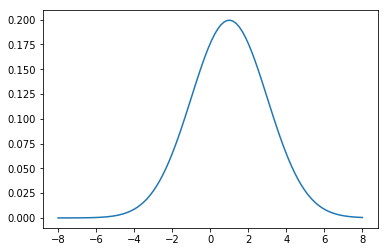

```python
xx = np.linspace(-8, 8, 100)
pdf = rv.pdf(xx)
plt.plot(xx, pdf)
plt.show()
```

### 누적 분포 함수

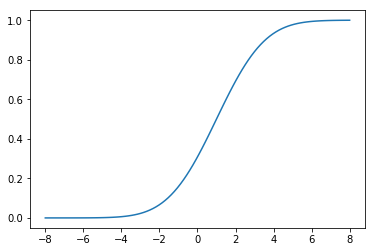

```python
xx = np.linspace(-8, 8, 100)
cdf = rv.cdf(xx)
plt.plot(xx, cdf)
plt.show()
```

### Generate ramdom sample

```python
rv.rvs(size=(3,5), random_state=0)
```

```
array([[ 4.52810469,  1.80031442,  2.95747597,  5.4817864 ,  4.73511598],
       [-0.95455576,  2.90017684,  0.69728558,  0.7935623 ,  1.821197  ],
       [ 1.28808714,  3.90854701,  2.52207545,  1.24335003,  1.88772647]])
```

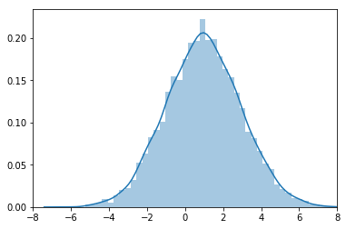

```python
sns.distplot(rv.rvs(size=10000, random_state=0))
plt.xlim(-8, 8)
plt.show()
```

### Reference

- https://datascienceschool.net